# Not-so-standardized effect sizes

Versions of Cohen’s *d* for dependent data

Ian Hussey

30 April, 2024

# Hypothetical study

Imagine that, like Balcetis & Dunning (2010), you want to answer a very simple question: how much do people prefer chocolate over poop?

- You have participants rate pictures of chocolate and pictures of poop from negative (1) to positive (7).
- How should you analyse this data to compare the mean evaluations of chocolate or poop? Should the test/effect size be independent or dependent?
- What version of Cohen’s d should you use to calculate the effect size?
- More mundanely, what implementation of this version of Cohen’s d should you use - i.e., which R package?

The specific choice of which version of Cohen’s d won’t affect the results that much… right? Studies and meta-analyses never make much distinction between them, so they must all be quite similar, right?

And since different packages implement the same math, they won’t produce different results, right? Right??

Let’s explore this in simulations.

```r
# Dependencies
# N.B.: to ensure full computational reproducibility, R version 4.3.3 should be used.

library(groundhog)

groundhog_day = "2024-04-07"

packages = c("effectsize","faux","janitor",
             "rstatix", "effsize",
             "psych", "MBESS", "lsr",
             "metafor", "esc", "esci",
             "dplyr", "tidyr", "tibble",
             "forcats", "ggplot2", "stringr")

groundhog.library(packages, groundhog_day)
```

# Functions

I have gathered many popular versions of Cohen’s d, both dependent and independent, and their implementations. Some of these I am still working to understand what label/name is appropriate for each package’s version of Cohen’s d.

```r
cohens_d_s_metafor <- function(data){
  # nb always applies hedges correction
  require(dplyr)
  require(tibble)
  require(metafor)

  summaries <- data |>
    group_by(timepoint) |>
    summarize(mean = mean(score),
              sd = sd(score),
              n = n()) |>
    pivot_wider(names_from = "timepoint",
                values_from = c("mean", "sd", "n"))

  fit <- escalc(measure = "SMD",
                m1i = mean_stimulus2,
                sd1i = sd_stimulus2,
                n1i = n_stimulus2,
                m2i = mean_stimulus1,
                sd2i = sd_stimulus1,
                n2i = n_stimulus1,
                data = summaries,
                append = FALSE)

  res <-
    tibble(estimate = fit$yi,
           ci_lower = fit$yi - sqrt(fit$vi)*1.96,
           ci_upper = fit$yi + sqrt(fit$vi)*1.96)
  return(res)
}


cohens_d_s_esc <- function(data, hedges_correction = TRUE){
  require(dplyr)
  require(tibble)
  require(esc)

  summaries <- data |>
    group_by(timepoint) |>
    summarize(mean = mean(score),
              sd = sd(score),
              n = n())

  fit <- esc::esc_mean_sd(grp1m  = summaries$mean[summaries$timepoint == "stimulus2"],
                          grp1sd = summaries$sd[summaries$timepoint == "stimulus2"],
                          grp1n  = summaries$n[summaries$timepoint == "stimulus2"],
                          grp2m  = summaries$mean[summaries$timepoint == "stimulus1"],
                          grp2sd = summaries$sd[summaries$timepoint == "stimulus1"],
                          grp2n  = summaries$n[summaries$timepoint == "stimulus1"],
                          es.type = ifelse(hedges_correction, "g", "d"))

  res <-
    tibble(estimate = fit$es,
           ci_lower = fit$ci.lo,
           ci_upper = fit$ci.hi)

  return(res)
}


cohens_d_z_esc <- function(data, hedges_correction = TRUE){
  require(dplyr)
  require(tibble)
  require(esc)

  summaries <- data |>
    group_by(timepoint) |>
    summarize(mean = mean(score),
              sd = sd(score),
              n = n())

  r <- data |>
    pivot_wider(names_from = "timepoint",
                values_from = "score") |>
    dplyr::select(-id) |>
    cor_test()

  fit <- esc::esc_mean_sd(grp1m  = summaries$mean[summaries$timepoint == "stimulus2"],
                          grp1sd = summaries$sd[summaries$timepoint == "stimulus2"],
                          grp1n  = summaries$n[summaries$timepoint == "stimulus2"],
                          grp2m  = summaries$mean[summaries$timepoint == "stimulus1"],
                          grp2sd = summaries$sd[summaries$timepoint == "stimulus1"],
                          grp2n  = summaries$n[summaries$timepoint == "stimulus1"],
                          r = r$cor,
                          es.type = ifelse(hedges_correction, "g", "d"))

  res <-
    tibble(estimate = fit$es,
           ci_lower = fit$ci.lo,
           ci_upper = fit$ci.hi)

  return(res)
}


cohens_d_s_rstatix <- function(data, hedges_correction = TRUE){
  require(dplyr)
  require(tibble)
  require(rstatix)

  fit <- rstatix::cohens_d(formula = score ~ timepoint,
                           data = data,
                           comparisons = list(c("stimulus1", "stimulus2")),
                           ref.group = "stimulus2",
                           paired = FALSE,
                           hedges.correction = hedges_correction,
                           ci = TRUE,
                           ci.type = "bca",
                           nboot = 2000)

  res <-
    tibble(estimate = fit$effsize,
           ci_lower = fit$conf.low,
           ci_upper = fit$conf.high)

  return(res)
}


cohens_d_z_rstatix <- function(data, hedges_correction = TRUE){
  require(dplyr)
  require(tibble)
  require(rstatix)

  fit <- rstatix::cohens_d(formula = score ~ timepoint,
                           data = data,
                           comparisons = list(c("stimulus1", "stimulus2")),
                           ref.group = "stimulus2",
                           paired = TRUE,
                           hedges.correction = hedges_correction,
                           ci = TRUE,
                           ci.type = "bca",
                           nboot = 2000)

  res <-
    tibble(estimate = fit$effsize,
           ci_lower = fit$conf.low,
           ci_upper = fit$conf.high)

  return(res)
}


# esci used to have a within subjects d in 2020 but now doesn't? and its not in the git history
cohens_d_s_esci <- function(data, hedges_correction = TRUE){
  require(dplyr)
  require(tibble)
  require(esci)

  summaries <- data |>
    group_by(timepoint) |>
    summarize(mean = mean(score),
              sd = sd(score),
              n = n())

  fit <- esci::CI_smd_ind_contrast(means = summaries$mean,
                                   sds = summaries$sd,
                                   ns = summaries$n,
                                   contrast = c(+1, -1),
                                   conf_level = 0.95,
                                   assume_equal_variance = FALSE,
                                   correct_bias = hedges_correction)

  res <-
    tibble(estimate = fit$effect_size,
           ci_lower = fit$LL,
           ci_upper = fit$UL)

  return(res)
}


cohens_d_s_effsize <- function(data, hedges_correction = TRUE){
  require(dplyr)
  require(tibble)
  require(effsize)

  fit <- effsize::cohen.d(score ~ timepoint,
                          paired = FALSE,
                          pooled = TRUE,
                          hedges.correction = hedges_correction,
                          data = data)

  res <-
    tibble(estimate = fit$estimate,
           ci_lower = fit$conf.int[1],
           ci_upper = fit$conf.int[2])

  return(res)
}


cohens_d_dep_effsize <- function(data, hedges_correction = TRUE){
  require(dplyr)
  require(tibble)
  require(effsize)

  fit <- effsize::cohen.d(score ~ timepoint | Subject(id),
                          paired = TRUE,
                          pooled = TRUE,
                          hedges.correction = hedges_correction,
                          data = data)
```

```r
  res <-
    tibble(estimate = fit$estimate,
           ci_lower = fit$conf.int[1],
           ci_upper = fit$conf.int[2])

  return(res)
}



cohens_d_s_psych <- function(data, hedges_correction = TRUE){
  require(dplyr)
  require(tibble)
  require(psych)

  fit <- psych::cohen.d(score ~ timepoint,
                        data = data)

  res <-
    tibble(estimate = ifelse(hedges_correction, fit$hedges.g[2]*-1, fit$cohen.d[2]*-1),
           ci_lower = ifelse(hedges_correction, min(fit$hedges.g*-1), min(fit$cohen.d*-1)),
           ci_upper = ifelse(hedges_correction, max(fit$hedges.g*-1), max(fit$cohen.d*-1)))

  return(res)
}



cohens_d_s_mbess <- function(data, hedges_correction = TRUE){
  require(dplyr)
  require(MBESS)

  d <- MBESS::smd(Group.1 = data |> filter(timepoint == "stimulus2") |> pull(score),
                  Group.2 = data |> filter(timepoint == "stimulus1") |> pull(score),
                  Unbiased = hedges_correction)

  t <- t.test(score ~ timepoint, data = data)$statistic

  cis <- ci.smd(ncp = t,
                #smd = d,
                n.1 = data |> filter(timepoint == "stimulus2") |> pull(score) |> length(),
                n.2 = data |> filter(timepoint == "stimulus1") |> pull(score) |> length())

  res <-
    data.frame(estimate = cis$smd,
               ci_lower = cis$Lower.Conf.Limit.smd,
               ci_upper = cis$Upper.Conf.Limit.smd)

  return(res)
}


cohens_d_s_lsr <- function(data){
  require(dplyr)
  require(tibble)
  require(lsr)

  # note that lsr::cohenD returns the absolute value of cohen's d, ie always positive values. fix this here to bring it in line with other packages' functions.
  mean_stimulus1 <- data |> dplyr::filter(timepoint == "stimulus1") |> summarize(mean = mean(score))
  mean_stimulus2 <- data |> dplyr::filter(timepoint == "stimulus2") |> summarize(mean = mean(score))

  d <- lsr::cohensD(score ~ timepoint,
                    data = data)

  res <-
    tibble(estimate = as.numeric(ifelse(mean_stimulus1 < mean_stimulus2, d, d * -1)),
           ci_lower = NA,
           ci_upper = NA)

  return(res)
}


cohens_d_dep_lsr <- function(data){
  require(dplyr)
  require(tibble)
  require(lsr)

  # note that lsr::cohenD returns the absolute value of cohen's d, ie always positive values. fix this here to bring it in line with other packages' functions.
  mean_stimulus1 <- data |> dplyr::filter(timepoint == "stimulus1") |> summarize(mean = mean(score))
  mean_stimulus2 <- data |> dplyr::filter(timepoint == "stimulus2") |> summarize(mean = mean(score))

  d <- lsr::cohensD(data |> dplyr::filter(timepoint == "stimulus1") |> pull(score),
                    data |> dplyr::filter(timepoint == "stimulus2") |> pull(score),
                    method = "paired")

  res <-
    tibble(estimate = as.numeric(ifelse(mean_stimulus1 < mean_stimulus2, d, d * -1)),
           ci_lower = NA,
           ci_upper = NA)

  return(res)
}


# assumes that 'data' contains columns named score (numeric) and timepoint (factor with two levels, stimulus1 and stimulus2, where positive cohen's d means higher scores at stimulus2)
# assumes a two sided Student's t test with alpha = .05
# by default, assumes correlation between timepoints is 0. larger values will narrow the CIs but leave the estimate unchanged. so, default result is the worst case stimulus1cision.
d_t_dependent <- function(data, hedges_correction = TRUE, r = 0) { # assumes a correlation of 0 for simplicity
  require(dplyr)

  fit <- t.test(data$score[data$timepoint == "stimulus2"],
                data$score[data$timepoint == "stimulus1"],
                paired = TRUE)

  res <-
    data.frame(t_stat = fit$statistic["t"],
               df = fit$parameter["df"],
               r = r) |>
    mutate(n = df + 1, # for dependent t test, n = df + 1
           dt_estimate = t_stat / sqrt(n), # for dependent t test, d_t = t / sqrt(n)
           dt_estimate = ifelse(hedges_correction,
                                dt_estimate * (1 - (3 / (4 * n - 9))),
                                dt_estimate),
           dt_se = sqrt((2 * (1 - r)) / n + (dt_estimate ^ 2) / (2 * n)), # default assumes a correlation of 0
           ci_lower = dt_estimate - (1.96 * dt_se),
           ci_upper = dt_estimate + (1.96 * dt_se),
           hedges_correction = hedges_correction) |>
    dplyr::select(hedges_correction, estimate = dt_estimate, ci_lower, ci_upper)

  return(res)
}


# cohen's d from a Student's t test (two sided, alpha = .05)
# if a Welches' t test, the conversion of df to N is imstimulus1cise, affecting the CIs.
# assumes that 'data' contains columns named score (numeric) and timepoint (factor with two levels)
d_t_independent <- function(data, hedges_correction = TRUE){
  require(dplyr)

  fit <- t.test(score ~ timepoint,
                data = data,
                paired = FALSE,
                var.equal = TRUE)

  res <-
    data.frame(t_stat = fit$statistic["t"],
               df = fit$parameter["df"]) |>
    mutate(n1 = data |> filter(timepoint == "stimulus2") |> nrow(),
           n2 = data |> filter(timepoint == "stimulus1") |> nrow(),
           dt_estimate = t_stat * sqrt(1/n1 + 1/n2), # d = t * sqrt(1/n1 + 1/n2) - from lakens 2013 equation 2
           dt_estimate = ifelse(hedges_correction,
                                dt_estimate * (1 - (3 / (4 * (n1+n2) - 9))),
                                dt_estimate),
           dt_se = sqrt((n1 + n2) / (n1 * n2) + (dt_estimate^2) / (2 * (n1 + n2 - 2))),
           ci_lower = dt_estimate - (1.96 * dt_se),
           ci_upper = dt_estimate + (1.96 * dt_se),
           hedges_correction = hedges_correction) |>
    dplyr::select(hedges_correction, estimate = dt_estimate, ci_lower, ci_upper)

  return(res)
}


multiple_cohens_ds_for_dependent_data <- function(data, hedges_correction = TRUE){

  # Check if 'data' is a dataframe or tibble
  if (!is.data.frame(data) && !is_tibble(data)) {
    stop("The 'data' argument must be a dataframe or tibble.")
  }

  # Check for 'score' column and its type
  if (!"score" %in% names(data) || !is.numeric(data$score)) {
    stop("The 'data' must contain a numeric column named 'score'.")
  }
```

```r
  # Check for 'timepoint' column, its type, and number of levels
  if (!"timepoint" %in% names(data)) {
    stop("The 'data' must contain a column named 'timepoint'.")
  }
  if (!is.factor(data$timepoint) && !is.character(data$timepoint)) {
    stop("The 'timepoint' column must be of type factor or character.")
  }

  # some pivots below assume only these columns are stimulus1sent
  data <- data |>
    select(id, timepoint, score)

  # Convert 'timepoint' to factor if it's not already
  data$timepoint <- as.factor(data$timepoint)

  # Check that 'timepoint' has exactly two levels
  if (nlevels(data$timepoint) != 2) {
    stop("The 'timepoint' column must have exactly two levels.")
  }

  results <-
    bind_rows(
      effectsize::cohens_d(score ~ timepoint, data = data, pooled_sd = TRUE, adjust = hedges_correction) |>
        as_tibble() |>
        mutate(type = "d_s",
               implementation = "{effectsize}",
               hedges_correction = hedges_correction) |>
        dplyr::select(implementation, type, hedges_correction, estimate = Hedges_g, ci_lower = CI_low, ci_upper = CI_high),

      cohens_d_s_psych(data = data, hedges_correction = hedges_correction) |>
        as_tibble() |>
        mutate(type = "d_s",
               implementation = "{psych}",
               hedges_correction = hedges_correction) |>
        dplyr::select(implementation, type, hedges_correction, estimate, ci_lower, ci_upper),

      cohens_d_s_mbess(data = data, hedges_correction = hedges_correction) |>
        mutate(type = "d_s",
               implementation = "{MBESS}",
               hedges_correction = hedges_correction) |>
        dplyr::select(implementation, type, hedges_correction, estimate, ci_lower, ci_upper),

      cohens_d_s_effsize(data = data, hedges_correction = hedges_correction) |>
        mutate(type = "d_s",
               implementation = "{effsize}",
               hedges_correction = hedges_correction) |>
        dplyr::select(implementation, type, hedges_correction, estimate, ci_lower, ci_upper),

      cohens_d_s_rstatix(data = data, hedges_correction = hedges_correction) |>
        mutate(type = "d_s",
               implementation = "{rstatix}",
               hedges_correction = hedges_correction) |>
        dplyr::select(implementation, type, hedges_correction, estimate, ci_lower, ci_upper),

      cohens_d_s_metafor(data = data) |>
        mutate(type = "d_s",
               implementation = "{metafor}",
               hedges_correction = TRUE) |> # nb always applies hedges correction
        dplyr::select(implementation, type, hedges_correction, estimate, ci_lower, ci_upper),

      cohens_d_z_rstatix(data = data, hedges_correction = hedges_correction) |>
        mutate(type = "d_z",
               implementation = "{rstatix}",
               hedges_correction = hedges_correction) |>
        dplyr::select(implementation, type, hedges_correction, estimate, ci_lower, ci_upper),

      cohens_d_s_esc(data = data, hedges_correction = hedges_correction) |>
        mutate(type = "d_s",
               implementation = "{esc}",
               hedges_correction = hedges_correction) |>
        dplyr::select(implementation, type, hedges_correction, estimate, ci_lower, ci_upper),

      cohens_d_z_esc(data = data, hedges_correction = hedges_correction) |>
        mutate(type = "d_??? (dep)",
               implementation = "{esc}",
               hedges_correction = hedges_correction) |>
        dplyr::select(implementation, type, hedges_correction, estimate, ci_lower, ci_upper),

      cohens_d_s_esci(data = data, hedges_correction = hedges_correction) |>
        mutate(type = "d_??? (indep)",
               implementation = "{esci}",
               hedges_correction = hedges_correction) |>
        dplyr::select(implementation, type, hedges_correction, estimate, ci_lower, ci_upper),

      cohens_d_dep_effsize(data = data, hedges_correction = hedges_correction) |>
        mutate(type = "d_??? (dep)",
               implementation = "{effsize}",
               hedges_correction = hedges_correction) |>
        dplyr::select(implementation, type, hedges_correction, estimate, ci_lower, ci_upper),

      cohens_d_s_lsr(data = data) |>
        mutate(type = "d_s",
               implementation = "{lsr}",
               hedges_correction = FALSE) |> # lsr doesn't have an option for hedges corrections
        dplyr::select(implementation, type, hedges_correction, estimate, ci_lower, ci_upper),

      cohens_d_dep_lsr(data = data) |>
        mutate(type = "d_z",
               implementation = "{lsr}",
               hedges_correction = FALSE) |> # lsr doesn't have an option for hedges corrections
        dplyr::select(implementation, type, hedges_correction, estimate, ci_lower, ci_upper),

      # this provides nearly identical results to d_s under most conditions
      # effectsize::cohens_d(score ~ timepoint, data = data, pooled_sd = FALSE, adjust = hedges_correction) |>
      #   as_tibble() |>
      #   mutate(type = "d_s_nonpooled",
      #          implementation = "{effectsize}",
      #          hedges_correction = hedges_correction) |>
      #   dplyr::select(implementation, type, hedges_correction, estimate = Hedges_g, ci_lower = CI_low, ci_upper = CI_high),

      effectsize::repeated_measures_d(score ~ timepoint | id, data = data, method = "d", adjust = hedges_correction) |>
        as_tibble() |>
        mutate(type = "d_s_withinCIs",
               implementation = "{effectsize}",
               hedges_correction = hedges_correction) |>
        dplyr::select(implementation, type, hedges_correction, estimate = Cohens_d, ci_lower = CI_low, ci_upper = CI_high),

      effectsize::repeated_measures_d(score ~ timepoint | id, data = data, method = "rm", adjust = hedges_correction) |>
        as_tibble() |>
        mutate(type = "d_rm",
               implementation = "{effectsize}",
               hedges_correction = hedges_correction) |>
        dplyr::select(implementation, type, hedges_correction, estimate = d_rm, ci_lower = CI_low, ci_upper = CI_high),
```

```r
      effectsize::repeated_measures_d(score ~ timepoint | id, data = data, method = "av", adjust = hedges_correction) |>
        as_tibble() |>
        mutate(type = "d_av",
               implementation = "{effectsize}",
               hedges_correction = hedges_correction) |>
        dplyr::select(implementation, type, hedges_correction, estimate = d_av, ci_lower = CI_low, ci_upper = CI_high),

      effectsize::repeated_measures_d(score ~ timepoint | id, data = data, method = "b", adjust = hedges_correction) |>
        as_tibble() |>
        mutate(type = "d_b",
               implementation = "{effectsize}",
               hedges_correction = hedges_correction) |>
        dplyr::select(implementation, type, hedges_correction, estimate = Beckers_d, ci_lower = CI_low, ci_upper = CI_high),

      # use timepoint stimulus2's SD rather than stimulus1.
      # this is useful to include as not all comparisons are stimulus1-stimulus2, some are the same participants rating stimulus X and Y, and either could be the reference
      data |>
        mutate(timepoint = fct_relevel(timepoint, "stimulus1", "stimulus2")) |>
        effectsize::repeated_measures_d(score ~ timepoint | id, data = _, method = "b", adjust = hedges_correction) |>
        as_tibble() |>
        mutate(type = "d_b (alt)",
               implementation = "{effectsize}",
               hedges_correction = hedges_correction,
               estimate = Beckers_d * -1,
               ci_lower = CI_high * -1,
               ci_upper = CI_low * -1) |>
        dplyr::select(implementation, type, hedges_correction, estimate, ci_lower, ci_upper),

      effectsize::repeated_measures_d(score ~ timepoint | id, data = data, method = "z", adjust = hedges_correction) |>
        as_tibble() |>
        mutate(type = "d_z",
               implementation = "{effectsize}",
               hedges_correction = hedges_correction) |>
        dplyr::select(implementation, type, hedges_correction, estimate = d_z, ci_lower = CI_low, ci_upper = CI_high),

      # this provides the same estimate as d_s
      d_t_independent(data = data, hedges_correction = hedges_correction) |>
        as_tibble() |>
        mutate(type = "d_t (independent)",
               implementation = "[custom]",
               hedges_correction = hedges_correction) |>
        dplyr::select(implementation, type, hedges_correction, estimate, ci_lower, ci_upper),

      # this provides the same estimate as d_z with slightly wider CIs
      d_t_dependent(data = data, hedges_correction = hedges_correction) |>
        as_tibble() |>
        mutate(type = "d_t (dependent, r = 0)",
               implementation = "[custom]",
               hedges_correction = hedges_correction) |>
        dplyr::select(implementation, type, hedges_correction, estimate, ci_lower, ci_upper)
    )
  return(results)
}


plot_different_dependent_cohens_ds <- function(parameters){
  data_for_simulations <-
    faux::rnorm_multi(n = parameters$simulation_n,
                      mu = c(stimulus1 = parameters$mean_stimulus1, stimulus2 = parameters$mean_stimulus2),
                      sd = c(parameters$sd_stimulus1, parameters$sd_stimulus2),
                      r = matrix(c(1, parameters$r_stimulus1_stimulus2,
                                   parameters$r_stimulus1_stimulus2, 1),
                                 ncol = 2)) |>
    rownames_to_column(var = "id") |>
    pivot_longer(cols = -id,
                 names_to = "timepoint",
                 values_to = "score") |>
    mutate(timepoint = fct_relevel(timepoint, "stimulus2", "stimulus1")) # ensure that factor levels are the in the correct order, especially for d_b

  simulation_results <- data_for_simulations |>
    multiple_cohens_ds_for_dependent_data() |>
    select(-hedges_correction) |>
    mutate(ci_width = ci_upper - ci_lower,
           sig = ifelse((ci_lower > 0 & ci_upper > 0) |
                          (ci_lower < 0 & ci_upper < 0) |
                          (is.na(ci_lower) & is.na(ci_upper)), TRUE, FALSE))

  plot <- ggplot(simulation_results, aes(paste(type, implementation), estimate, color = sig)) +
    geom_hline(yintercept = 0, linetype = "dashed") +
    geom_linerange(aes(ymin = ci_lower, ymax = ci_upper), size = 0.8) +
    geom_point(position = position_dodge(width = 0.5), size = 1.8) +
    scale_y_continuous(breaks = scales::pretty_breaks()) +
    coord_flip() +
    theme_linedraw() +
    xlab("") +
    ylab("Cohen's d") +
    scale_color_viridis_d(begin = 0.2, end = 0.5, option = "D") +
    theme(legend.position = "none",
          panel.grid.minor = element_blank())

  return(plot)
}
```

# Simulate data

## Simulation 1

Small effect size, equal variances, very large correlation between ratings.

```r
set.seed(42)

parameters <-
  data.frame(simulation_n = 100,
             mean_stimulus1 = 0,
             mean_stimulus2 = 0.2,
             sd_stimulus1 = 1,
             sd_stimulus2 = 1,
             r_stimulus1_stimulus2 = 0.9)

parameters |>
  pivot_longer(cols = everything(),
               names_to = "parameter",
               values_to = "value") |>
  knitr::kable()
```

| parameter | value |
| --- | --- |
| simulation_n | 100.0 |
| mean_stimulus1 | 0.0 |
| mean_stimulus2 | 0.2 |
| sd_stimulus1 | 1.0 |
| sd_stimulus2 | 1.0 |
| r_stimulus1_stimulus2 | 0.9 |

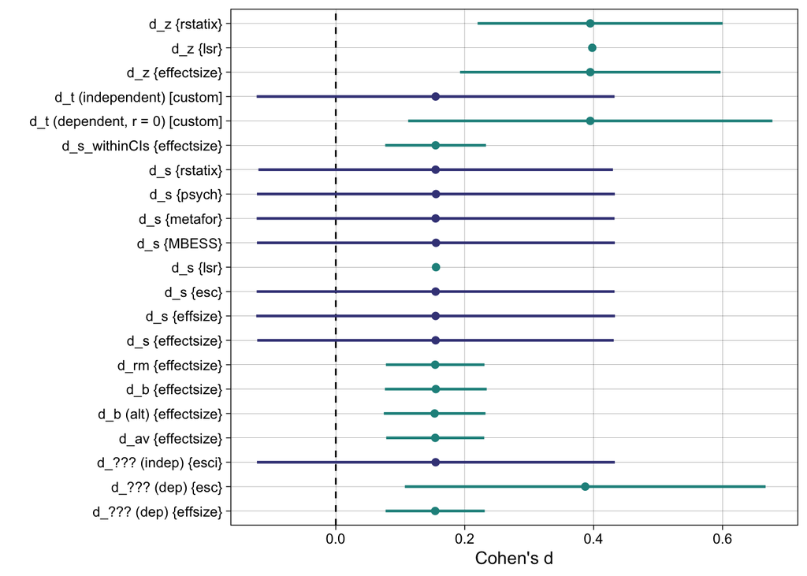

```r
plot_different_dependent_cohens_ds(parameters)
```

## Simulation 2

Small effect size, equal variances, small correlation between ratings.

```r
set.seed(42)

parameters <-
  data.frame(simulation_n = 100,
             mean_stimulus1 = 0,
             mean_stimulus2 = 0.2,
             sd_stimulus1 = 1,
             sd_stimulus2 = 1,
             r_stimulus1_stimulus2 = 0.1)

parameters |>
  pivot_longer(cols = everything(),
               names_to = "parameter",
               values_to = "value") |>
  knitr::kable()
```

| parameter | value |
| --- | --- |
| simulation_n | 100.0 |
| mean_stimulus1 | 0.0 |
| mean_stimulus2 | 0.2 |
| sd_stimulus1 | 1.0 |
| sd_stimulus2 | 1.0 |
| r_stimulus1_stimulus2 | 0.1 |

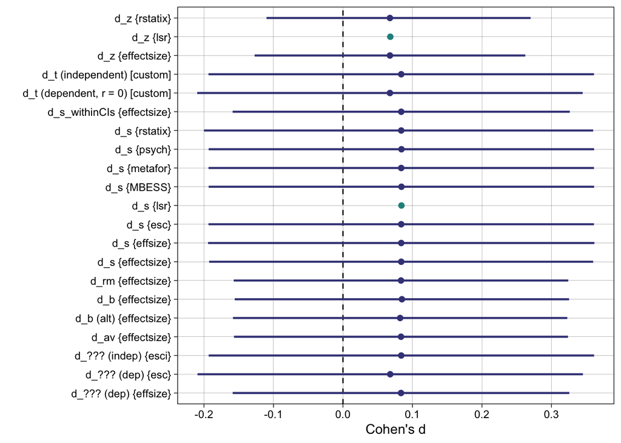

```r
plot_different_dependent_cohens_ds(parameters)
```

## Simulation 3

Small effect size, unequal variances, large correlation between ratings.

```r
set.seed(42)

parameters <-
  data.frame(simulation_n = 100,
             mean_stimulus1 = 0,
             mean_stimulus2 = 0.2,
             sd_stimulus1 = 0.5,
             sd_stimulus2 = 1.5,
             r_stimulus1_stimulus2 = 0.5)

parameters |>
  pivot_longer(cols = everything(),
               names_to = "parameter",
               values_to = "value") |>
  knitr::kable()
```

| parameter | value |
| --- | --- |
| simulation_n | 100.0 |
| mean_stimulus1 | 0.0 |
| mean_stimulus2 | 0.2 |
| sd_stimulus1 | 0.5 |
| sd_stimulus2 | 1.5 |
| r_stimulus1_stimulus2 | 0.5 |

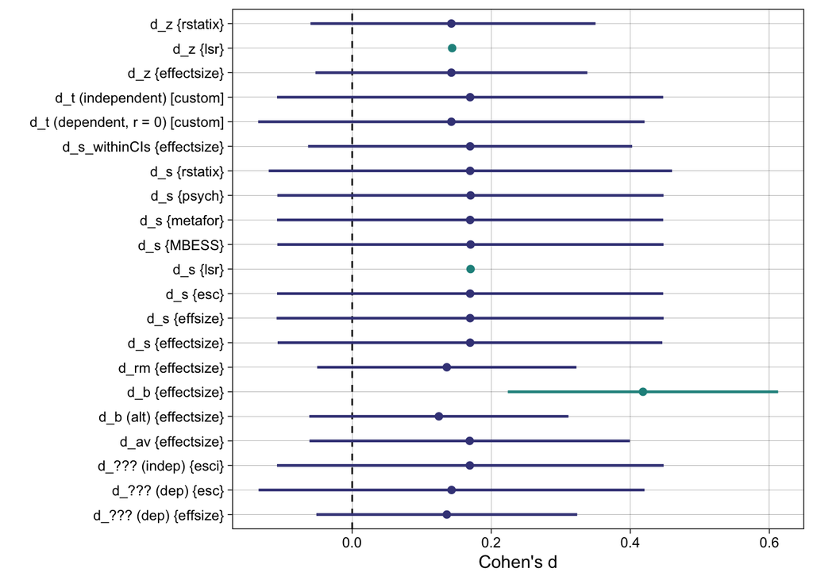

```r
plot_different_dependent_cohens_ds(parameters)
```

## Simulation 4

Plausible parameters for preference between chocolate and poop on a 1 to 7 Likert scale.

```r
set.seed(42)

parameters <-
  data.frame(simulation_n = 100,
             mean_stimulus1 = 1.5,
             mean_stimulus2 = 6.5,
             sd_stimulus1 = 1.5,
             sd_stimulus2 = 1.5,
             r_stimulus1_stimulus2 = -0.75)

parameters |>
  pivot_longer(cols = everything(),
               names_to = "parameter",
               values_to = "value") |>
  knitr::kable()
```

| parameter | value |
| --- | --- |
| simulation_n | 100.00 |
| mean_stimulus1 | 1.50 |
| mean_stimulus2 | 6.50 |
| sd_stimulus1 | 1.50 |
| sd_stimulus2 | 1.50 |
| r_stimulus1_stimulus2 | -0.75 |

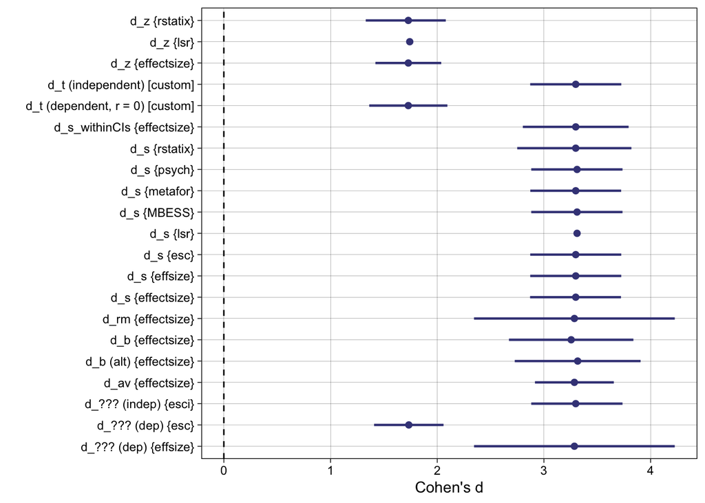

```r
plot_different_dependent_cohens_ds(parameters)
```